# Vowel duration

Stefano Coretta

# Import data

Let’s read the files.

```r
vowels <- list.files(path = "pilot/results",
                   pattern = "*-vowel-durations.csv",
                   full.names = TRUE) %>%
    map_df(~read_csv(., na = "--undefined--"))
languages <- read_csv("./pilot/stimuli/languages.csv")
words <- read_csv("./pilot/stimuli/nonce.csv")
vowels <- left_join(vowels, languages) %>%
    left_join(y = words) %>%
    mutate_if(is.character, as.factor) %>%
    mutate(index = as.factor(index))
vowels.it <- filter(vowels, language == "italian")
vowels.pl <- filter(vowels, language == "polish")
```

# Italian

## Word duration

```r
word.it <- lmer(
    word.duration ~
        c2phonation +
        c1phonation +
        vowel +
        sentence.duration +
        (1|speaker) +
        (1|word),
    data = vowels.it
)

summary(word.it)
```

```
## Linear mixed model fit by REML ['lmerMod']
## Formula:
## word.duration ~ c2phonation + c1phonation + vowel + sentence.duration +
##     (1 | speaker) + (1 | word)
##    Data: vowels.it
##
## REML criterion at convergence: 2479.1
##
## Scaled residuals:
##     Min      1Q  Median      3Q     Max
## -2.9602 -0.5511 -0.0375  0.5767  5.2667
##
## Random effects:
##  Groups   Name        Variance Std.Dev.
##  word     (Intercept)    0      0.00
##  speaker  (Intercept) 3128     55.93
##  Residual              810     28.46
## Number of obs: 263, groups:  word, 24; speaker, 2
##
## Fixed effects:
##                      Estimate Std. Error t value
## (Intercept)          -112.747     53.990  -2.088
## c2phonationvoiceless   14.594      3.511   4.157
## c1phonationvoiceless   -9.047      3.510  -2.577
## vowelo                  5.820      4.356   1.336
## vowelu                  9.100      4.306   2.113
## sentence.duration     334.892     21.298  15.724
##
## Correlation of Fixed Effects:
##             (Intr) c2phnt c1phnt vowelo vowelu
## c2phntnvcls -0.048
## c1phntnvcls -0.042 -0.004
## vowelo       0.066 -0.008  0.003
## vowelu      -0.016 -0.006  0.004  0.502
## sentnc.drtn -0.677  0.023  0.013 -0.155 -0.035
```

```r
mixed(
    word.duration ~
        c2phonation +
        c1phonation +
        vowel +
        sentence.duration +
        (1|word),
    data = vowels.it
)
```

```
## Numerical variables NOT centered on 0 (i.e., interpretation of all main effects might be difficult if in interactions): sentence.duration
```

```
## Fitting 5 (g)lmer() models:
## [.....]
## Obtaining 4 p-values:
## [....]
```

```
##              Effect        df F.scaling           F p.value
## 1       c2phonation  1, 18.96      1.00    13.03 **    .002
## 2       c1phonation  1, 18.96      1.00      4.09 +     .06
## 3             vowel  2, 19.07      1.00        1.55     .24
## 4 sentence.duration 1, 246.78      1.00 1730.30 ***  <.0001
```

In Italian, words with voiceless stops are longer.

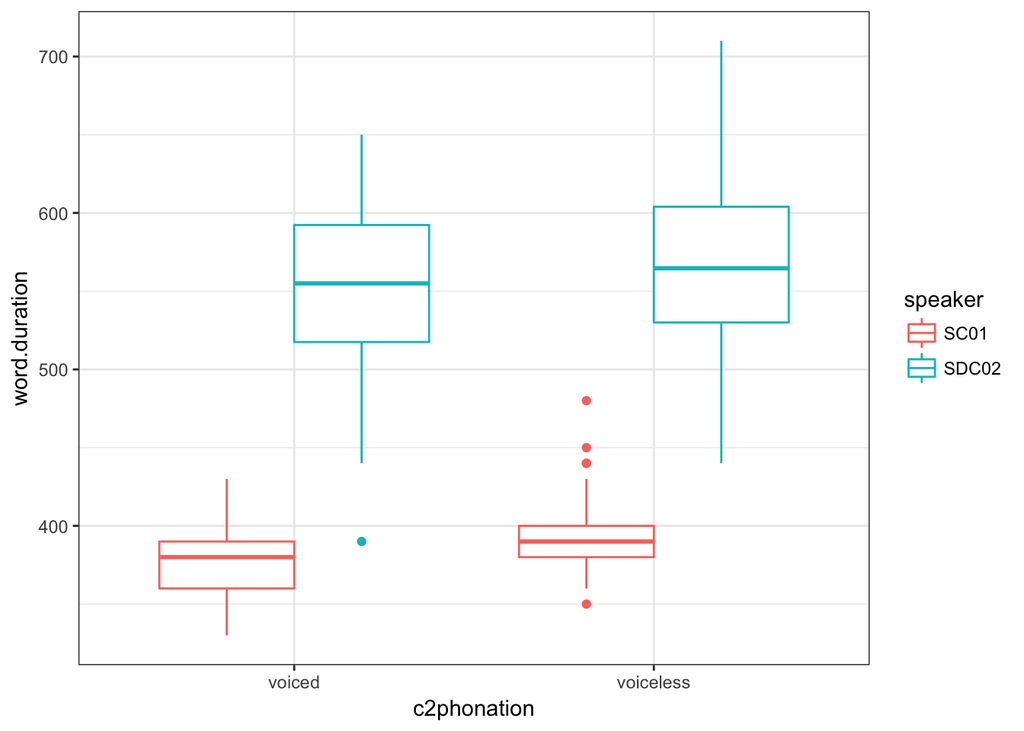

```r
ggplot(vowels.it, aes(c2phonation, word.duration, colour = speaker)) +
    geom_boxplot()
```

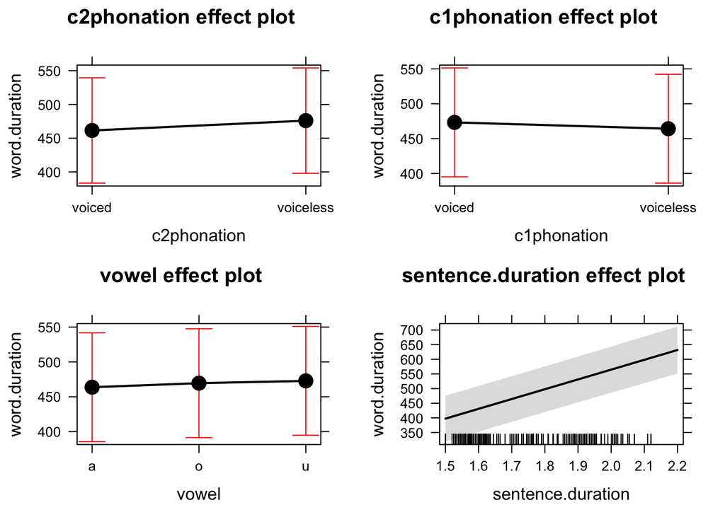

```r
plot(allEffects(word.it))
```

## Consonant closure duration and phonation

```r
model.closvoic.it <- lmer(
    closure.duration ~
        c2phonation +
        vowel +
        c1phonation +
        c2place +
        sentence.duration +
        (1|word) +
        (1|speaker),
    data = vowels.it
)

summary(model.closvoic.it)
```

```
## Linear mixed model fit by REML ['lmerMod']
## Formula: closure.duration ~ c2phonation + vowel + c1phonation + c2place +
##     sentence.duration + (1 | word) + (1 | speaker)
##    Data: vowels.it
##
## REML criterion at convergence: 1567.5
##
## Scaled residuals:
##     Min      1Q  Median      3Q     Max
## -3.9650 -0.5506  0.0281  0.6083  3.0254
##
## Random effects:
##  Groups   Name        Variance Std.Dev.
##  word     (Intercept)  24.09    4.909
##  speaker  (Intercept) 421.98   20.542
##  Residual             116.38   10.788
## Number of obs: 207, groups:  word, 24; speaker, 2
##
## Fixed effects:
##                      Estimate Std. Error t value
## (Intercept)            -6.288     22.274  -0.282
## c2phonationvoiceless   18.804      2.557   7.355
## vowelo                  4.987      3.128   1.594
## vowelu                 -2.674      3.076  -0.869
## c1phonationvoiceless   -2.397      2.528  -0.948
## c2placevelar           -6.037      2.534  -2.382
## sentence.duration      48.422      9.639   5.023
##
## Correlation of Fixed Effects:
##             (Intr) c2phnt vowelo vowelu c1phnt c2plcv
## c2phntnvcls -0.084
## vowelo       0.006 -0.032
## vowelu      -0.039 -0.003  0.497
## c1phntnvcls -0.059 -0.007  0.010  0.009
## c2placevelr -0.073  0.032 -0.007  0.002  0.005
## sentnc.drtn -0.745  0.027 -0.096 -0.041  0.002  0.016
```

```r
mixed(
    closure.duration ~
        c2phonation +
        vowel +
        c1phonation +
        c2place +
        sentence.duration +
        (1|word) +
        (1|speaker),
    data = vowels.it
)
```

```
## Numerical variables NOT centered on 0 (i.e., interpretation of all main effects might be difficult if in interactions): sentence.duration
```

```
## Fitting 6 (g)lmer() models:
## [......]
## Obtaining 5 p-values:
## [.....]
```

```
##              Effect        df F.scaling         F p.value
## 1       c2phonation  1, 18.81      1.00 54.03 ***  <.0001
## 2             vowel  2, 17.89      1.00    3.09 +     .07
## 3       c1phonation  1, 17.67      1.00      0.90     .36
## 4           c2place  1, 17.83      1.00    5.66 *     .03
## 5 sentence.duration 1, 190.36      1.00 24.20 ***  <.0001
```

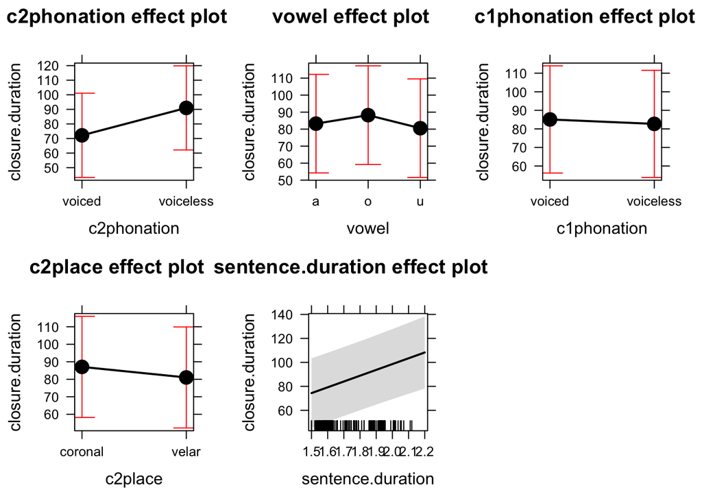

```r
plot(allEffects(model.closvoic.it))
```

## Vowel duration and phonation

Fit a mixed effect linear model for Italian.

```r
model.it <- lmer(
    vowel.duration ~
        c2phonation *
        vowel +
        c1phonation +
        c2place +
        c2place:vowel +
        sentence.duration +
        (1|word) +
        (1|speaker),
    data = vowels.it
)

summary(model.it)
```

```
## Linear mixed model fit by REML ['lmerMod']
## Formula: vowel.duration ~ c2phonation * vowel + c1phonation + c2place +
##     c2place:vowel + sentence.duration + (1 | word) + (1 | speaker)
##    Data: vowels.it
##
## REML criterion at convergence: 2069.2
##
## Scaled residuals:
##     Min      1Q  Median      3Q     Max
## -3.2114 -0.6910 -0.0223  0.5949  2.9340
##
## Random effects:
##  Groups   Name        Variance Std.Dev.
##  word     (Intercept)   9.643   3.105
##  speaker  (Intercept) 127.132  11.275
##  Residual             178.321  13.354
## Number of obs: 263, groups:  word, 24; speaker, 2
##
## Fixed effects:
##                             Estimate Std. Error t value
## (Intercept)                   40.652     19.366   2.099
## c2phonationvoiceless         -21.658      3.615  -5.991
## vowelo                        -2.778      4.408  -0.630
## vowelu                       -34.660      4.406  -7.866
## c1phonationvoiceless          -6.729      2.079  -3.237
## c2placevelar                   1.475      3.609   0.409
## sentence.duration             76.524     10.054   7.612
## c2phonationvoiceless:vowelo   -3.190      5.108  -0.624
## c2phonationvoiceless:vowelu   15.385      5.096   3.019
## vowelo:c2placevelar           -3.967      5.094  -0.779
## vowelu:c2placevelar          -17.416      5.095  -3.419
##
## Correlation of Fixed Effects:
##                             (Intr) c2phnt vowelo vowelu c1phnt c2plcv
## c2phntnvcls                 -0.143
## vowelo                      -0.091  0.407
## vowelu                      -0.115  0.409  0.500
## c1phntnvcls                 -0.062 -0.004 -0.002 -0.002
## c2placevelr                 -0.099  0.008  0.409  0.410 -0.004
## sentnc.drtn                 -0.895  0.056 -0.026  0.002  0.010  0.007
```

[output cut: 11 more lines]

```
## c2phonationvoiceless:vowelo -0.074
## c2phonationvoiceless:vowelu -0.023  0.502
## vowelo:c2plcvlr             -0.007  0.004
## vowelu:c2plcvlr             -0.009  0.004
##                             c2phonationvoiceless:vowelu vowelo:c2plcvlr
## c2phntnvcls
## vowelo
## vowelu
## c1phntnvcls
## c2placevelr
## sentnc.drtn
## c2phonationvoiceless:vowelo
## c2phonationvoiceless:vowelu
## vowelo:c2plcvlr              0.004
## vowelu:c2plcvlr              0.004                       0.502
```

```r
mixed(
    vowel.duration ~
        c2phonation *
        vowel +
        c1phonation +
        c2place +
        c2place:vowel +
        sentence.duration +
        (1|word) +
        (1|speaker),
    data = vowels.it
)
```

```
## Numerical variables NOT centered on 0 (i.e., interpretation of all main effects might be difficult if in interactions): sentence.duration
```

```
## Fitting 8 (g)lmer() models:
## [........]
## Obtaining 7 p-values:
## [.......]
```

```
##              Effect        df F.scaling         F p.value
## 1       c2phonation  1, 14.12      1.00 35.87 ***  <.0001
## 2             vowel  2, 13.87      1.00 38.23 ***  <.0001
## 3       c1phonation  1, 13.91      1.00  10.48 **    .006
## 4           c2place  1, 14.04      1.00      0.17     .69
## 5 sentence.duration 1, 206.40      1.00 50.43 ***  <.0001
## 6 c2phonation:vowel  2, 13.98      1.00   7.62 **    .006
## 7     vowel:c2place  2, 13.90      1.00    6.43 *     .01
```

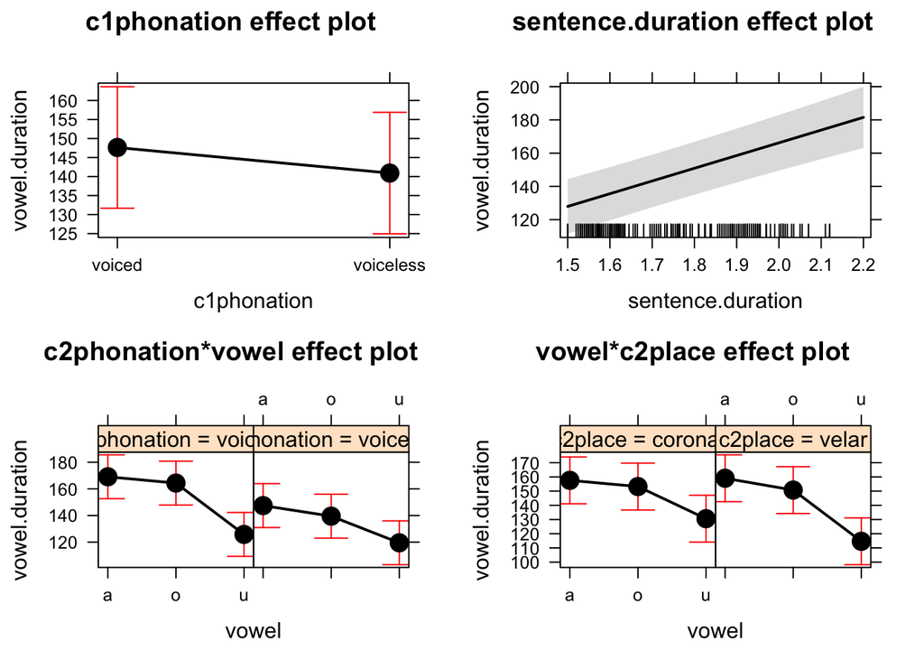

```r
plot(allEffects(model.it))
```

C2 voicing and vowel identity have an effect on vowel duration, although there is an interaction between those two terms. Low and mid-low vowels have a stronger voicing effect than the high vowel. But, see below: if you add an interaction with closure duration, vowel identity is not significant anymore.

## Vowel duration and consonant closure duration

```r
model.closure.it <- lmer(
    vowel.duration ~
        vowel *
        closure.duration *
        c2place +
        c1phonation +
        sentence.duration +
        (1|word) +
        (1|speaker),
    data = vowels.it
)

summary(model.closure.it)
```

```
## Linear mixed model fit by REML ['lmerMod']
## Formula:
## vowel.duration ~ vowel * closure.duration * c2place + c1phonation +
##     sentence.duration + (1 | word) + (1 | speaker)
##    Data: vowels.it
##
## REML criterion at convergence: 1560.3
##
## Scaled residuals:
##     Min      1Q  Median      3Q     Max
## -3.0779 -0.5849  0.0439  0.5379  3.8106
##
## Random effects:
##  Groups   Name        Variance Std.Dev.
##  word     (Intercept)  35.09    5.923
##  speaker  (Intercept) 251.81   15.868
##  Residual             107.15   10.352
## Number of obs: 207, groups:  word, 24; speaker, 2
##
## Fixed effects:
##                                       Estimate Std. Error t value
## (Intercept)                            6.54056   21.39853   0.306
## vowelo                                15.66250   10.15970   1.542
## vowelu                                11.99658   10.87711   1.103
## closure.duration                      -0.27088    0.10025  -2.702
## c2placevelar                          -5.70075    9.77657  -0.583
## c1phonationvoiceless                  -9.23476    2.84512  -3.246
## sentence.duration                    102.51924    9.95966  10.293
## vowelo:closure.duration               -0.23974    0.10918  -2.196
## vowelu:closure.duration               -0.47619    0.12270  -3.881
## vowelo:c2placevelar                  -12.71617   13.23536  -0.961
## vowelu:c2placevelar                   -9.13759   14.43254  -0.633
## closure.duration:c2placevelar          0.10122    0.10671   0.949
## vowelo:closure.duration:c2placevelar   0.07977    0.13980   0.571
## vowelu:closure.duration:c2placevelar  -0.13284    0.16543  -0.803
```

```
##
## Correlation matrix not shown by default, as p = 14 > 12.
## Use print(x, correlation=TRUE)  or
##   vcov(x)     if you need it
```

```r
mixed(
    vowel.duration ~
        vowel *
        closure.duration *
        c2place +
        c1phonation +
        sentence.duration +
        (1|word) +
        (1|speaker),
    data = vowels.it
)
```

```
## Numerical variables NOT centered on 0 (i.e., interpretation of all main effects might be difficult if in interactions): closure.duration, sentence.duration
```

```
## Fitting 10 (g)lmer() models:
## [..........]
## Obtaining 9 p-values:
## [.........]
```

```
##                           Effect        df F.scaling          F p.value
## 1                          vowel 2, 106.01      1.00       1.21     .30
## 2               closure.duration 1, 131.44      1.00    6.84 **    .010
## 3                        c2place  1, 99.76      1.00       0.33     .57
## 4                    c1phonation  1, 15.67      1.00   10.51 **    .005
## 5              sentence.duration 1, 187.61      1.00 101.65 ***  <.0001
## 6         vowel:closure.duration 2, 171.19      1.00   7.29 ***   .0009
## 7                  vowel:c2place 2, 110.39      1.00       0.47     .63
## 8       closure.duration:c2place 1, 186.79      1.00       0.87     .35
## 9 vowel:closure.duration:c2place 2, 189.65      1.00       0.92     .40
```

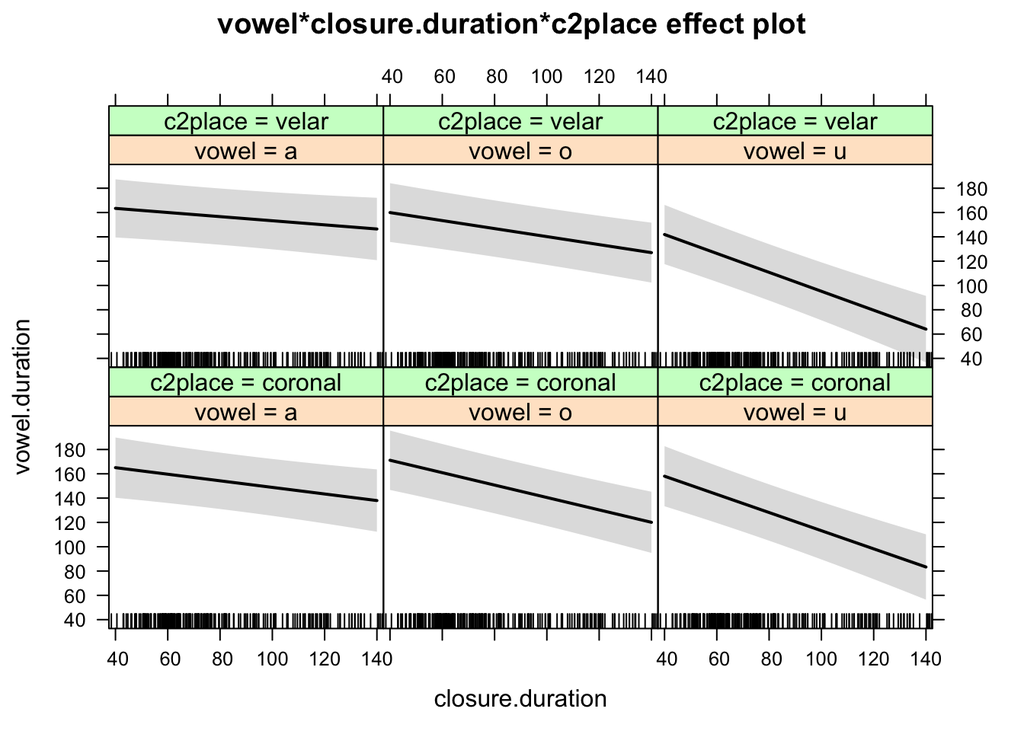

```r
plot(allEffects(model.closure.it)[3])
```

There is an iteraction between closure duration and vowel identity: the high vowel has a stronger effect of closure duration on vowel duration (cf. with not so strong effect of voicing). But, vowel identity on itself is not significant.

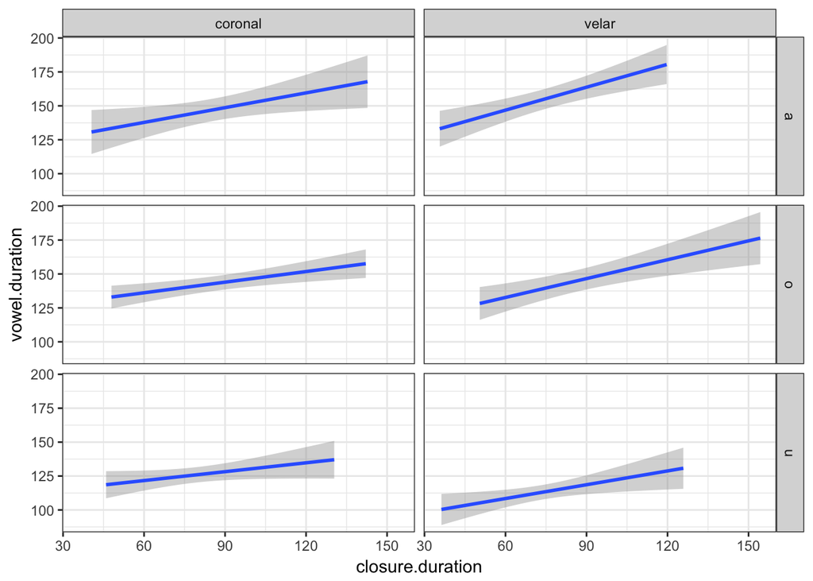

```r
ggplot(vowels.it, aes(closure.duration, vowel.duration)) +
    geom_smooth(method = "lm") +
    facet_grid(vowel ~ c2place)
```

## Vowel duration and consonant duration

The following includes closure and RVOT duration.

```r
model.consonants.it <- lmer(
    vowel.duration ~
        c2.duration *
        vowel *
        c2place +
        c1phonation +
        sentence.duration +
        (1|word) +
        (1|speaker),
    data = vowels.it
)

summary(model.consonants.it)
```

```
## Linear mixed model fit by REML ['lmerMod']
## Formula: vowel.duration ~ c2.duration * vowel * c2place + c1phonation +
##     sentence.duration + (1 | word) + (1 | speaker)
##    Data: vowels.it
##
## REML criterion at convergence: 1579
##
## Scaled residuals:
##     Min      1Q  Median      3Q     Max
## -3.1728 -0.5972  0.0151  0.5747  3.5682
##
## Random effects:
##  Groups   Name        Variance Std.Dev.
##  word     (Intercept)  25.29    5.029
##  speaker  (Intercept) 153.40   12.386
##  Residual             120.79   10.991
## Number of obs: 207, groups:  word, 24; speaker, 2
##
## Fixed effects:
##                                  Estimate Std. Error t value
## (Intercept)                       7.65484   21.11939   0.362
## c2.duration                      -0.22069    0.09340  -2.363
## vowelo                           19.68069   11.39224   1.728
## vowelu                           -0.37731   11.32990  -0.033
## c2placevelar                     -1.24006   11.56011  -0.107
## c1phonationvoiceless             -9.37532    2.59596  -3.612
## sentence.duration               100.20152   10.36125   9.671
## c2.duration:vowelo               -0.23561    0.11130  -2.117
## c2.duration:vowelu               -0.27990    0.11658  -2.401
## c2.duration:c2placevelar          0.07571    0.11141   0.680
## vowelo:c2placevelar             -21.65029   15.49856  -1.397
## vowelu:c2placevelar              -3.50455   16.74675  -0.209
## c2.duration:vowelo:c2placevelar   0.15108    0.14408   1.049
## c2.duration:vowelu:c2placevelar  -0.07860    0.16238  -0.484
```

```
##
## Correlation matrix not shown by default, as p = 14 > 12.
## Use print(x, correlation=TRUE)  or
##   vcov(x)     if you need it
```

```r
mixed(
    vowel.duration ~
        c2.duration *
        vowel *
        c2place +
        c1phonation +
        sentence.duration +
        (1|word) +
        (1|speaker),
    data = vowels.it
)
```

```
## Numerical variables NOT centered on 0 (i.e., interpretation of all main effects might be difficult if in interactions): c2.duration, sentence.duration
```

```
## Fitting 10 (g)lmer() models:
## [..........]
## Obtaining 9 p-values:
## [.........]
```

```
##                      Effect        df F.scaling         F p.value
## 1               c2.duration  1, 96.93      1.00    5.20 *     .02
## 2                     vowel  2, 95.16      1.00      2.06     .13
## 3                   c2place 1, 104.28      1.00      0.01     .92
## 4               c1phonation  1, 14.40      1.00  13.00 **    .003
## 5         sentence.duration 1, 183.20      1.00 85.88 ***  <.0001
## 6         c2.duration:vowel 2, 123.04      1.00    3.20 *     .04
## 7       c2.duration:c2place 1, 143.22      1.00      0.44     .51
## 8             vowel:c2place 2, 107.92      1.00      1.12     .33
## 9 c2.duration:vowel:c2place 2, 145.70      1.00      1.24     .29
```

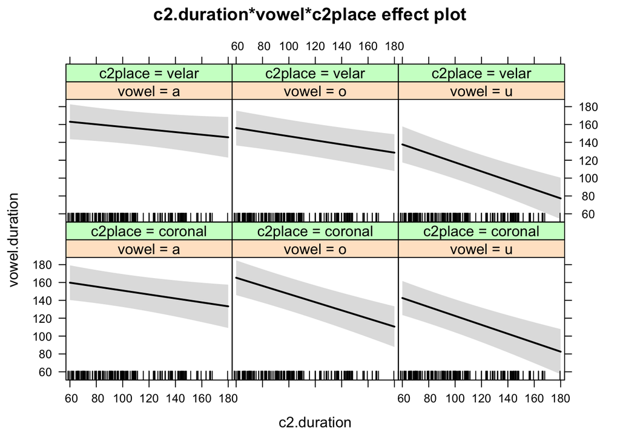

```r
plot(allEffects(model.consonants.it)[3])
```

It would be worth probably measuring vowel height in terms of tongue distance from the palate.

# Polish

## Word duration

```r
word.pl <- lmer(
    word.duration ~
        c2phonation +
        vowel +
        sentence.duration +
        (1|word),
    data = vowels.pl
)

summary(word.pl)
```

```
## Linear mixed model fit by REML ['lmerMod']
## Formula: word.duration ~ c2phonation + vowel + sentence.duration + (1 |
##     word)
##    Data: vowels.pl
##
## REML criterion at convergence: 806.8
##
## Scaled residuals:
##      Min       1Q   Median       3Q      Max
## -2.25467 -0.58918  0.04655  0.63759  2.01168
##
## Random effects:
##  Groups   Name        Variance Std.Dev.
##  word     (Intercept)  10.22    3.197
##  Residual             356.18   18.873
## Number of obs: 96, groups:  word, 12
##
## Fixed effects:
##                      Estimate Std. Error t value
## (Intercept)           -56.305     35.993  -1.564
## c2phonationvoiceless   -3.127      4.304  -0.727
## vowelo                  6.282      5.408   1.162
## vowelu                  4.581      5.713   0.802
## sentence.duration     415.781     36.463  11.403
##
## Correlation of Fixed Effects:
##             (Intr) c2phnt vowelo vowelu
## c2phntnvcls -0.181
## vowelo       0.181 -0.031
## vowelu       0.332 -0.049  0.545
## sentnc.drtn -0.993  0.123 -0.253 -0.402
```

```r
mixed(
    word.duration ~
        c2phonation +
        vowel +
        sentence.duration +
        (1|word),
    data = vowels.pl
)
```

```
## Numerical variables NOT centered on 0 (i.e., interpretation of all main effects might be difficult if in interactions): sentence.duration
```

```
## Fitting 4 (g)lmer() models:
## [....]
## Obtaining 3 p-values:
## [...]
```

```
##              Effect       df F.scaling          F p.value
## 1       c2phonation  1, 7.95      1.00       0.53     .49
## 2             vowel  2, 8.92      1.00       0.69     .53
## 3 sentence.duration 1, 87.88      1.00 121.78 ***  <.0001
```

It seems there is no diffirence in duration between words with a voiceless stop and words with a voiced stop in Polish.

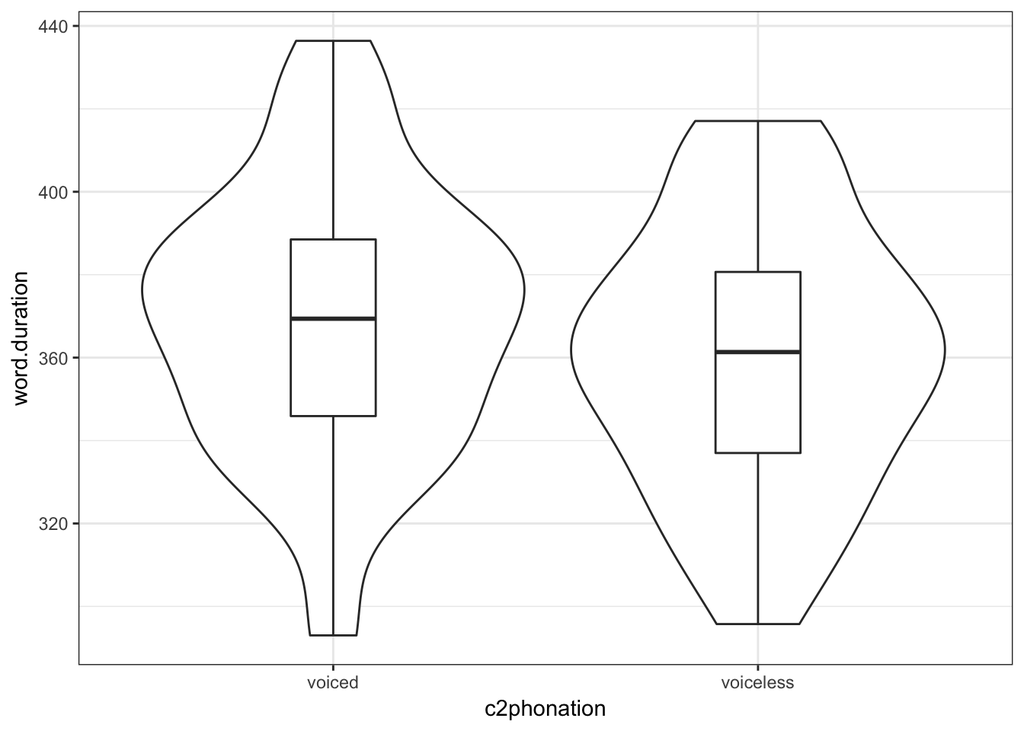

```r
ggplot(vowels.pl, aes(c2phonation, word.duration)) +
    geom_violin() +
    geom_boxplot(width = 0.2)
```

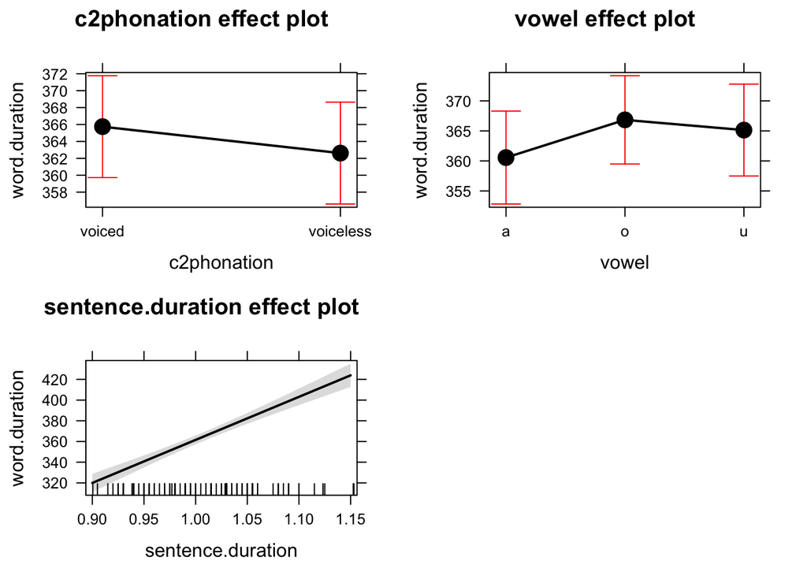

```r
plot(allEffects(word.pl))
```

## Consonant closure duration and phonation

```r
closure.pl <- lmer(
    closure.duration ~
        c2phonation +
        vowel +
        sentence.duration +
        (1|word),
    data = vowels.pl
)

summary(closure.pl)
```

```
## Linear mixed model fit by REML ['lmerMod']
## Formula: closure.duration ~ c2phonation + vowel + sentence.duration +
##     (1 | word)
##    Data: vowels.pl
##
## REML criterion at convergence: 651.9
##
## Scaled residuals:
##      Min       1Q   Median       3Q      Max
## -2.85853 -0.58002 -0.01783  0.63981  2.32425
##
## Random effects:
##  Groups   Name        Variance Std.Dev.
##  word     (Intercept) 51.46    7.173
##  Residual             93.74    9.682
## Number of obs: 90, groups:  word, 12
##
## Fixed effects:
##                      Estimate Std. Error t value
## (Intercept)            -6.108     21.551  -0.283
## c2phonationvoiceless   10.440      4.637   2.251
## vowelo                  2.930      5.736   0.511
## vowelu                 12.110      5.833   2.076
## sentence.duration      50.850     21.480   2.367
##
## Correlation of Fixed Effects:
##             (Intr) c2phnt vowelo vowelu
## c2phntnvcls -0.184
## vowelo       0.027 -0.012
## vowelu       0.108 -0.019  0.518
## sentnc.drtn -0.977  0.078 -0.161 -0.241
```

```r
mixed(
    closure.duration ~
        c2phonation +
        vowel +
        sentence.duration +
        (1|word),
    data = vowels.pl
)
```

```
## Numerical variables NOT centered on 0 (i.e., interpretation of all main effects might be difficult if in interactions): sentence.duration
```

```
## Fitting 4 (g)lmer() models:
## [....]
## Obtaining 3 p-values:
## [...]
```

```
##              Effect       df F.scaling      F p.value
## 1       c2phonation  1, 8.01      1.00 5.07 +     .05
## 2             vowel  2, 8.38      1.00   2.37     .15
## 3 sentence.duration 1, 82.22      1.00 5.48 *     .02
```

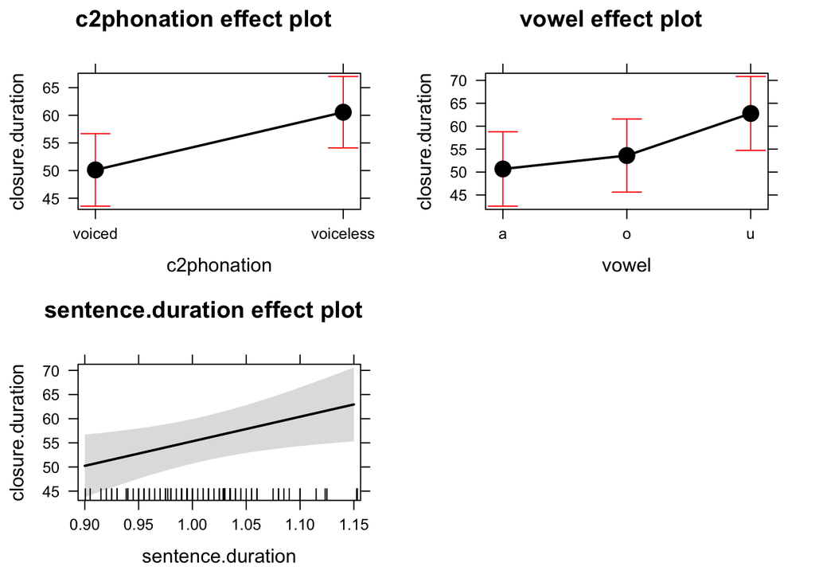

```r
plot(allEffects(closure.pl))
```

In Polish, the closure duration of voiced stops is smaller than that of voiceless stops.

## Vowel duration and phonation

Fit a mixed effect linear model for Polish

```r
model.pl <- lmer(
    vowel.duration ~
        c2phonation *
        vowel +
        c2place +
        sentence.duration +
        (1|word),
    data = vowels.pl
)

summary(model.pl)
```

```
## Linear mixed model fit by REML ['lmerMod']
## Formula:
## vowel.duration ~ c2phonation * vowel + c2place + sentence.duration +
##     (1 | word)
##    Data: vowels.pl
##
## REML criterion at convergence: 713.8
##
## Scaled residuals:
##     Min      1Q  Median      3Q     Max
## -2.1636 -0.7201 -0.0834  0.4724  2.2496
##
## Random effects:
##  Groups   Name        Variance Std.Dev.
##  word     (Intercept)  26.77    5.174
##  Residual             150.53   12.269
## Number of obs: 96, groups:  word, 12
##
## Fixed effects:
##                             Estimate Std. Error t value
## (Intercept)                   41.919     24.592   1.705
## c2phonationvoiceless          -8.927      6.758  -1.321
## vowelo                       -11.742      6.803  -1.726
## vowelu                       -32.715      6.981  -4.686
## c2placevelar                  -6.688      3.899  -1.715
## sentence.duration             56.419     24.624   2.291
## c2phonationvoiceless:vowelo    2.121      9.551   0.222
## c2phonationvoiceless:vowelu    9.648      9.559   1.009
##
## Correlation of Fixed Effects:
##                             (Intr) c2phnt vowelo vowelu c2plcv sntnc.
## c2phntnvcls                 -0.177
## vowelo                      -0.017  0.491
## vowelu                       0.115  0.473  0.511
## c2placevelr                 -0.055 -0.001  0.003  0.006
## sentnc.drtn                 -0.978  0.040 -0.122 -0.254 -0.024
## c2phonationvoiceless:vowelo  0.117 -0.707 -0.699 -0.337  0.000 -0.020
## c2phonationvoiceless:vowelu  0.051 -0.704 -0.356 -0.695 -0.001  0.047
##                             c2phonationvoiceless:vowelo
## c2phntnvcls
## vowelo
## vowelu
## c2placevelr
## sentnc.drtn
## c2phonationvoiceless:vowelo
## c2phonationvoiceless:vowelu  0.498
```

```r
mixed(vowel.duration ~
          c2phonation *
          vowel +
          c2place +
          sentence.duration +
          (1|word),
      data = vowels.pl
)
```

```
## Numerical variables NOT centered on 0 (i.e., interpretation of all main effects might be difficult if in interactions): sentence.duration
```

```
## Fitting 6 (g)lmer() models:
## [......]
## Obtaining 5 p-values:
## [.....]
```

```
##              Effect       df F.scaling       F p.value
## 1       c2phonation  1, 4.88      1.00    1.74     .25
## 2             vowel  2, 5.17      1.00 11.24 *     .01
## 3           c2place  1, 4.87      1.00    2.94     .15
## 4 sentence.duration 1, 87.64      1.00  4.97 *     .03
## 5 c2phonation:vowel  2, 4.88      1.00    0.56     .60
```

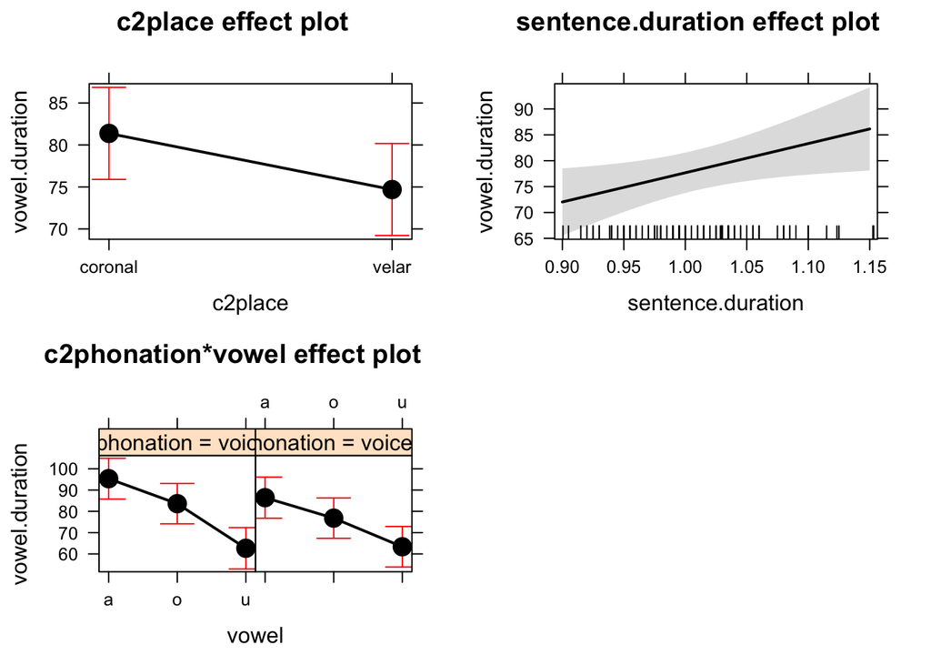

```r
plot(allEffects(model.pl))
```

[u] is shorter than [a] and [o]. The interaction between voicing and vowel identity is in the same direction as with Italian but voicing is not significant (nor is the interaction). But, see below.

## Vowel duration and consonant closure duration

```r
vowels.closure.pl <- lmer(
    vowel.duration ~
        closure.duration *
        vowel *
        c2place +
        sentence.duration +
        (1|word),
    data = vowels.pl
)

summary(vowels.closure.pl)
```

```
## Linear mixed model fit by REML ['lmerMod']
## Formula:
## vowel.duration ~ closure.duration * vowel * c2place + sentence.duration +
##     (1 | word)
##    Data: vowels.pl
##
## REML criterion at convergence: 656.6
##
## Scaled residuals:
##      Min       1Q   Median       3Q      Max
## -1.93216 -0.62818 -0.03184  0.55557  2.53661
##
## Random effects:
##  Groups   Name        Variance Std.Dev.
##  word     (Intercept)   0.0     0.00
##  Residual             137.1    11.71
## Number of obs: 90, groups:  word, 12
##
## Fixed effects:
##                                      Estimate Std. Error t value
## (Intercept)                           18.9595    30.5041   0.622
## closure.duration                      -0.1163     0.2467  -0.472
## vowelo                                37.9928    24.1802   1.571
## vowelu                                 4.3928    17.3768   0.253
## c2placevelar                          23.9258    19.4117   1.232
## sentence.duration                     74.5503    27.8145   2.680
## closure.duration:vowelo               -0.8425     0.4857  -1.735
## closure.duration:vowelu               -0.3833     0.3363  -1.140
## closure.duration:c2placevelar         -0.3563     0.3901  -0.913
## vowelo:c2placevelar                  -61.6393    35.1017  -1.756
## vowelu:c2placevelar                  -68.8608    28.4973  -2.416
## closure.duration:vowelo:c2placevelar   0.9685     0.6612   1.465
## closure.duration:vowelu:c2placevelar   0.8602     0.5023   1.713
```

```
##
## Correlation matrix not shown by default, as p = 13 > 12.
## Use print(x, correlation=TRUE)  or
##   vcov(x)     if you need it
```

```r
mixed(
    vowel.duration ~
        closure.duration *
        vowel *
        c2place +
        sentence.duration +
        (1|word),
    data = vowels.pl
)
```

```
## Numerical variables NOT centered on 0 (i.e., interpretation of all main effects might be difficult if in interactions): closure.duration, sentence.duration
```

```
## Fitting 9 (g)lmer() models:
## [.........]
## Obtaining 8 p-values:
## [........]
```

```
##                           Effect       df F.scaling      F p.value
## 1               closure.duration 1, 21.43      1.00   0.17     .68
## 2                          vowel 2, 28.09      1.00   1.00     .38
## 3                        c2place  1, 9.99      1.00   1.14     .31
## 4              sentence.duration 1, 75.91      1.00 6.67 *     .01
## 5         closure.duration:vowel 2, 31.30      1.00   1.30     .29
## 6       closure.duration:c2place 1, 11.79      1.00   0.62     .45
## 7                  vowel:c2place 2, 19.79      1.00 2.61 +     .10
## 8 closure.duration:vowel:c2place 2, 20.23      1.00   1.35     .28
```

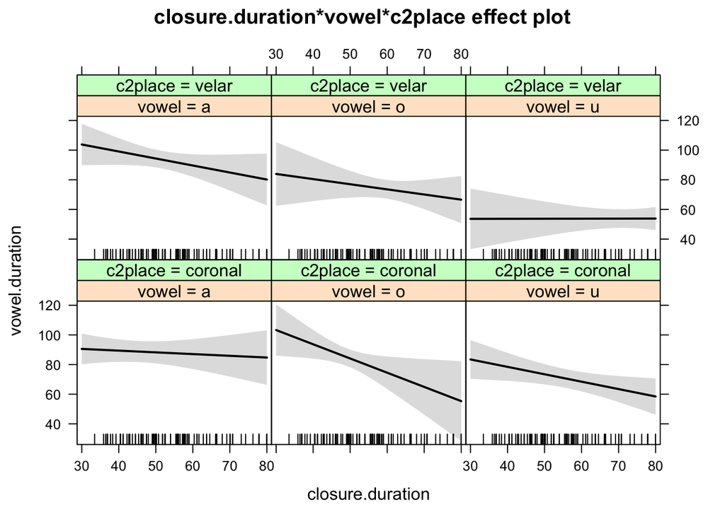

```r
plot(allEffects(vowels.closure.pl)[2])
```

# Inter-speaker variation

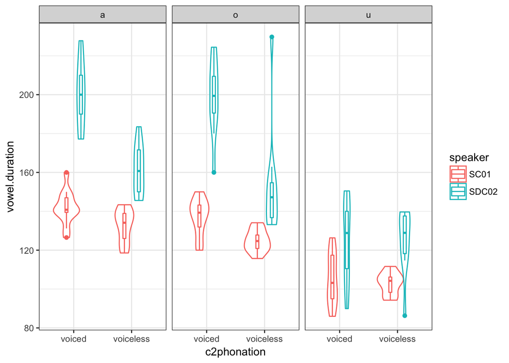

```r
dodge <- position_dodge(width = 0.5)

ggplot(filter(vowels.it, c2place == "velar"), aes(c2phonation, vowel.duration, colour = speaker)) +
    facet_grid(. ~ vowel) +
    geom_violin(position = dodge) +
    geom_boxplot(width=0.1, position = dodge)
```

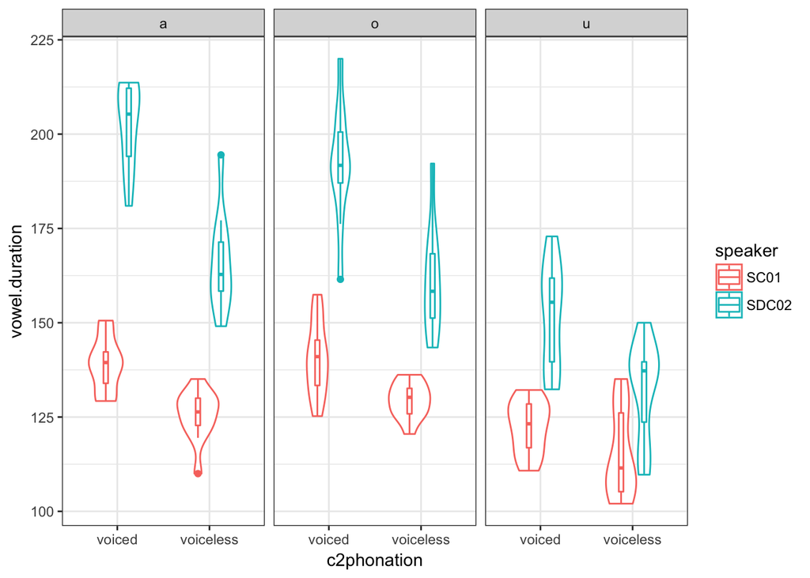

```r
ggplot(filter(vowels.it, c2place == "coronal"), aes(c2phonation, vowel.duration, colour = speaker)) +
    facet_grid(. ~ vowel) +
    geom_violin(position = dodge) +
    geom_boxplot(width=0.1, position = dodge)
```

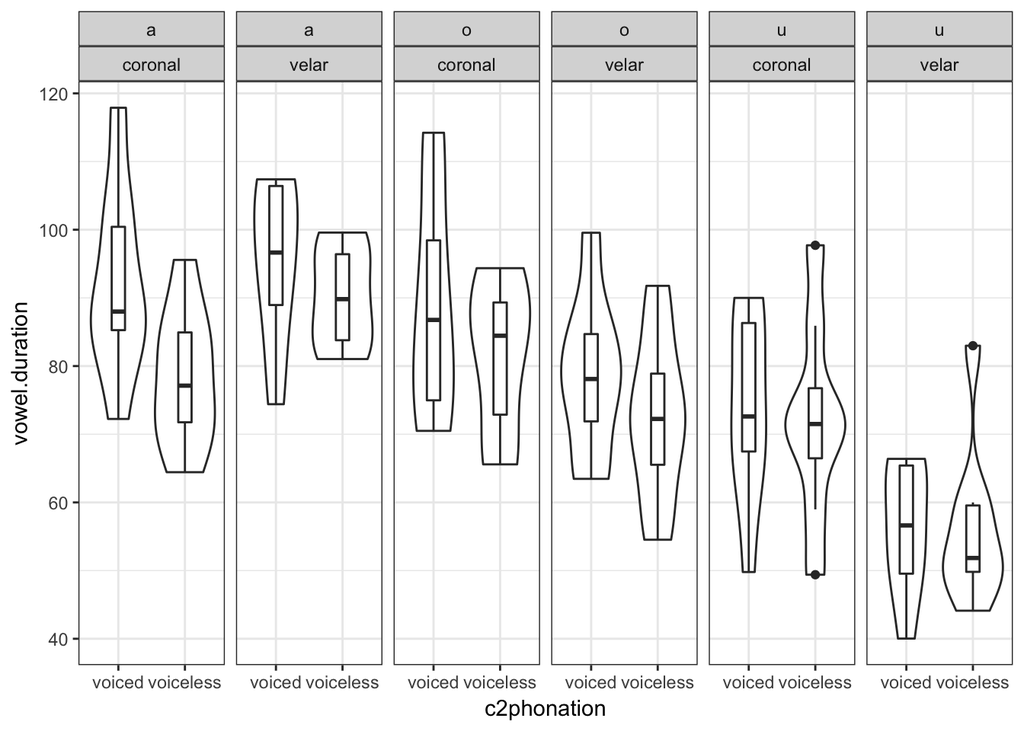

```r
ggplot(vowels.pl, aes(c2phonation, vowel.duration)) +
    facet_grid(. ~ vowel + c2place) +
    geom_violin() +
    geom_boxplot(width=0.2)
```

# Proportions

```r
proportions <- vowels %>%
    group_by(c2phonation, language) %>%
    summarise(
        total = mean(vowel.duration, na.rm = TRUE) +
            mean(closure.duration, na.rm = TRUE) +
            mean(rvt, na.rm = TRUE),
        vowel = mean(vowel.duration, na.rm = TRUE) / total,
        closure = mean(closure.duration, na.rm = TRUE) / total,
        rvt = mean(rvt, na.rm = TRUE) / total
    ) %>%
    gather(segment, duration, vowel:rvt) %>%
    mutate(segment = factor(segment, levels = c("rvt", "closure", "vowel")))
```

The following graph is misleading, because the VOR in Italian and in Polish is not constant in the voiceless and voiced conditions.

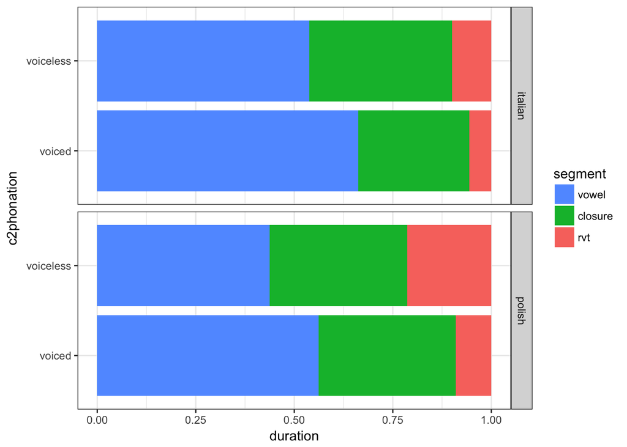

```r
ggplot(proportions, aes(c2phonation, duration, fill = segment)) +
    geom_bar(stat = "identity") +
    coord_flip() +
    facet_grid(language ~ .) +
    guides(fill = guide_legend(reverse = TRUE))
```

```r
word.proportions <- vowels %>%
    group_by(c1phonation, c2phonation, language) %>%
    summarise(
        total =
            mean(c1.duration, na.rm = TRUE) +
            mean(vowel.duration, na.rm = TRUE) +
            mean(closure.duration, na.rm = TRUE) +
            mean(rvt, na.rm = TRUE) +
            mean(v2.duration, na.rm = TRUE),
        c1 = mean(c1.duration, na.rm = TRUE),
        vowel = mean(vowel.duration, na.rm = TRUE),
        closure = mean(closure.duration, na.rm = TRUE),
        rvt = mean(rvt, na.rm = TRUE),
        v2 = mean(v2.duration, na.rm = TRUE)
    ) %>%
    gather(segment, duration, c1:v2) %>%
    mutate(segment = factor(segment,
                            levels = c("v2", "rvt", "closure", "vowel", "c1")
                            )
           ) %>%
    unite(phonation, c1phonation, c2phonation)
```

In Italian, the first C and the last vowel are held constant, while in Polish is the foot and the stressed vowel?

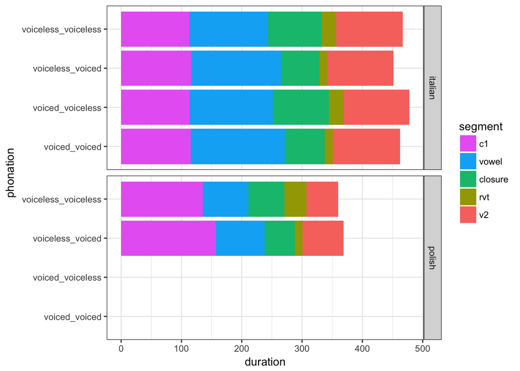

```r
ggplot(word.proportions, aes(phonation, duration, fill = segment)) +
    geom_bar(stat = "identity") +
    coord_flip() +
    facet_grid(language ~ .) +
    guides(fill = guide_legend(reverse = TRUE))
```